# CP006: BMV vs Volkswagen

Valentina Díaz Torres

26/11/2020

## Modelo GARCH BMV

En primer lugar se va a realizar un Modelo GARCH de la empresa BMW, teniendo en cuenta los datos desde 2014 hasta hoy.

```r
library("quantmod") #Package to download financials historical data
library(forecast)
library("fGarch")
library(vars)
```

```r
#funciones
archTest <- function(rtn,m=10){

  y=(rtn-mean(rtn))^2
  T=length(rtn)
  atsq=y[(m+1):T]
  x=matrix(0,(T-m),m)
  for (i in 1:m){
    x[,i]=y[(m+1-i):(T-i)]
  }
  md=lm(atsq~x)
  summary(md)
}
```

```r
#Carga de datos de BMW y Volkswagen
BSymbol="BMW.DE"
VSymbol="VOW3.DE"
#seleccionar los datos desde 2014 hasta hoy
mData<-getSymbols(BSymbol ,from="2014-01-01",to="2020-11-26",auto.assign=FALSE)
mData1<-getSymbols(VSymbol ,from="2014-01-01",to="2020-11-26",auto.assign=FALSE)
#Definir datos
xData=Ad(mData)
xData1=Ad(mData1)
#Calcular la rentabilidad diaria
dRentCont=dailyReturn(xData,type='log',leading=FALSE)
dRentCont1=dailyReturn(xData1,type='log',leading=FALSE)
#Excluir NA's
dRentCont=na.exclude(dRentCont)
dRentCont=na.exclude(dRentCont)
```

Una vez cargados los datos, se va a estudiar la rentabilidad diaria de la empresa en el tiempo estipulado.

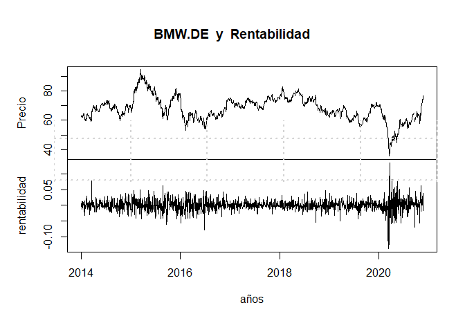

```r
#plot de zoo de los datos de BMW
plot.zoo(cbind(xData,dRentCont),main=paste(BSymbol," y  Rentabilidad"),xlab="años",ylab=c("Precio","rentabilidad"))
grid(lwd=2)
```

El gráfico anterior nos muestra cómo ha sido la rentabilidad del mismo. Se puede observar que con la crisis del Covid, los precios cayeron, pero que luego fueron remontando progresivamente. No obstante, comparando la rentabilidad con la de dos años atrás, esta era muy estable, mientras que a partir del Covid ha dejado de serlo.

## Volatilidad de GARCH

La volatilidad es calculada mediante la rentabilidad al cuadrado, ya que como tal no es medible, es este el estimador usado.

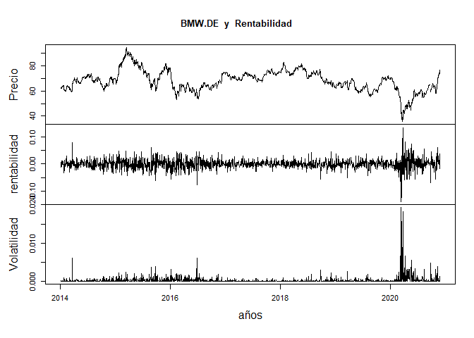

```r
#Plot return squared
plot.zoo(cbind(Ad(mData),dRentCont,dRentCont^2),main=paste(BSymbol," y  Rentabilidad"),xlab="años",ylab=c("Precio","rentabilidad","Volatilidad"))
```

En este gráfico se pueden ver los efectos de la volatilidad, como medida de riesgo comparados con el precio y la rentabilidad. Todos coinciden en el punto del Covid, comentado anteriormente.

Para la identificación y diagnosis de GARCH se han realizado los tests que aparecen a continuación.

**Testing mean**

```r
t.test(dRentCont)
```

[output not shown]

**ACF y PACF de los rendimientos al cuadrado**

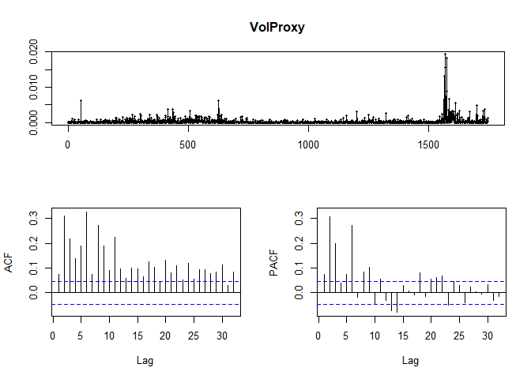

```r
VolProxy=dRentCont^2 #al cuadrado para conocer la volatilidad
#gráfico
tsdisplay(VolProxy)
```

En los gráficos de este test, se puede apreciar como no hay ruido blanco y por tanto hay autocorrelación.

**Ljung-Box Test**

```r
#Ljung-Box Test
Box.test(VolProxy,lag=10,  type="Lj")
Box.test(VolProxy,lag=20,  type="Lj")
Box.test(VolProxy,lag=40,  type="Lj")
```

[output not shown]

**LM test**

```r
archTest(dRentCont,20)
```

[output not shown]

**Pruebas GARCH (1,0) y GARCH (1,1)**

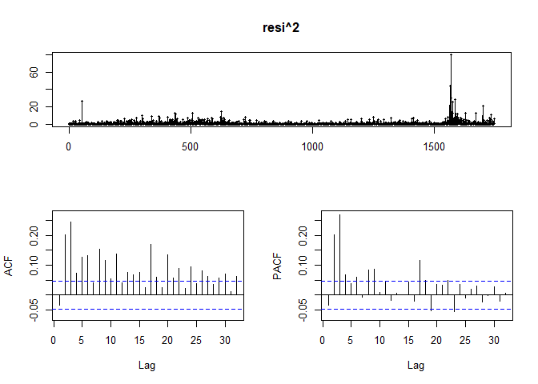

```r
#ARCH(1)
m1=garchFit(~1+garch(1,0),data=dRentCont,trace=F) # Fit an ARCH(1) model
#summary(m1)
resi=residuals(m1,standardize=T) #residuals
resi=xts(resi,order.by=index(dRentCont)) #residuals as xts
tsdisplay(resi^2) #acf pacf residuals
```

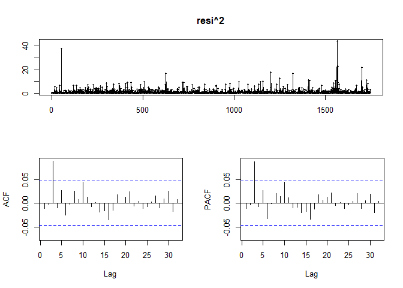

```r
#GARCH(1,1)
m2=garchFit(~1+garch(1,1),data=dRentCont,trace=F) # Fit an GARCH(1,1) model
#summary(m2)

resi=residuals(m2,standardize=T) #residuals
resi=xts(resi,order.by=index(dRentCont)) #residuals as xts
tsdisplay(resi^2) #acf pacf residuals
```

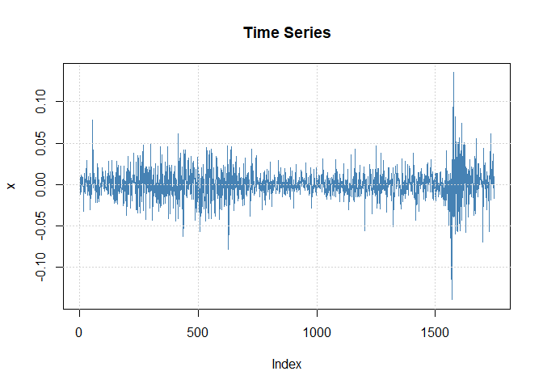

```r
plot(m2, which = 1)
```

**T-student**

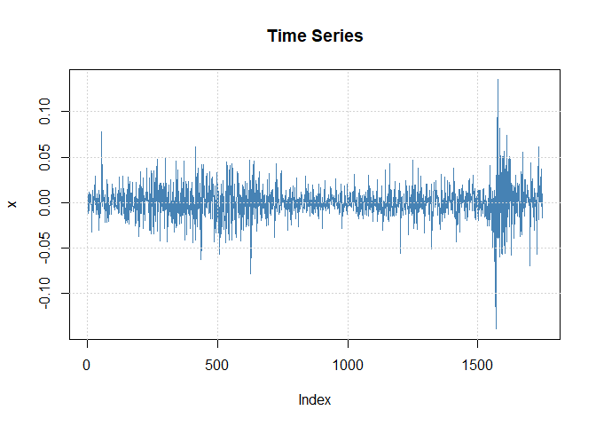

```r
#t-student
m3=garchFit(~1+garch(1,1),data=dRentCont,trace=F,cond.dist="std")
#summary(m3)
plot(m3 , which = 1)
```

A continuación se puede observar la volatilidad estudiada de BMW, que e dispara a principio de 2020 con el covid.

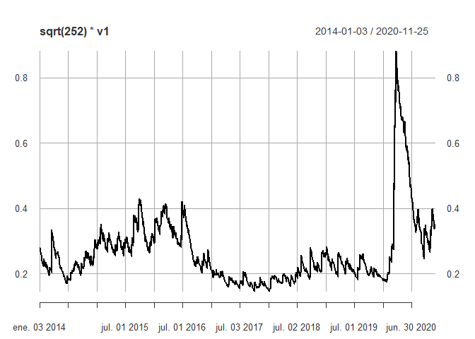

```r
v1=volatility(m3)  #volatilidad
v1=xts(v1,order.by=index(dRentCont)) #volatilidad con xts0
plot(sqrt(252)*v1)
```

**Residuos**

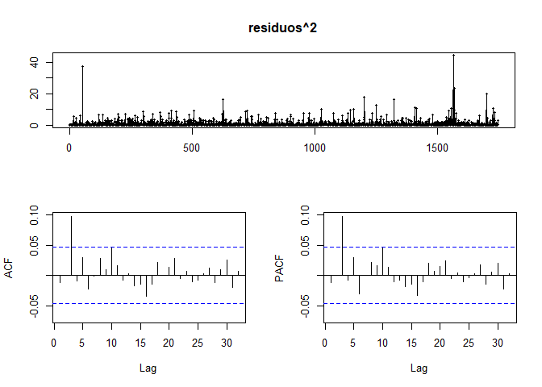

```r
residuos=residuals(m3,standardize=T) # Standardized residuals
resi=xts(residuos,order.by=index(dRentCont)) # Standardized residuals as XTS
tsdisplay(residuos^2) #acf pacf residuals
```

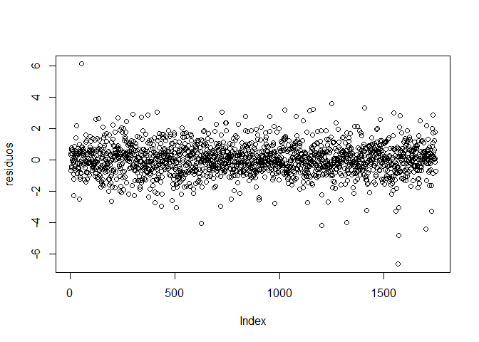

```r
plot(residuos)
```

**Predicción Forecast**

```r
predict(m3) #volatilidad forecast
```

```
##    meanForecast  meanError standardDeviation
## 1  1.390915e-05 0.02198594        0.02198594
## 2  1.390915e-05 0.02198043        0.02198043
## 3  1.390915e-05 0.02197494        0.02197494
## 4  1.390915e-05 0.02196947        0.02196947
## 5  1.390915e-05 0.02196403        0.02196403
## 6  1.390915e-05 0.02195861        0.02195861
## 7  1.390915e-05 0.02195321        0.02195321
## 8  1.390915e-05 0.02194784        0.02194784
## 9  1.390915e-05 0.02194250        0.02194250
## 10 1.390915e-05 0.02193718        0.02193718
```

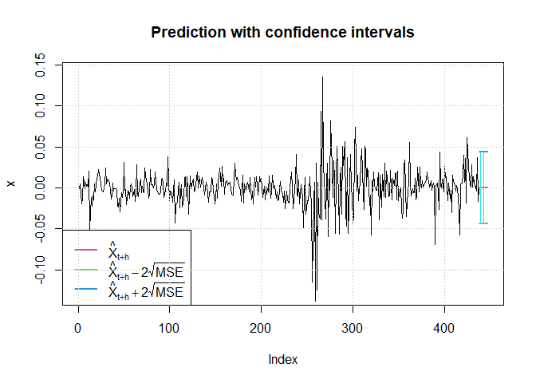

```
##    meanForecast  meanError standardDeviation lowerInterval upperInterval
## 1  1.390915e-05 0.02198594        0.02198594   -0.04395797    0.04398579
## 2  1.390915e-05 0.02198043        0.02198043   -0.04394694    0.04397476
## 3  1.390915e-05 0.02197494        0.02197494   -0.04393596    0.04396378
## 4  1.390915e-05 0.02196947        0.02196947   -0.04392503    0.04395285
## 5  1.390915e-05 0.02196403        0.02196403   -0.04391414    0.04394196
## 6  1.390915e-05 0.02195861        0.02195861   -0.04390331    0.04393113
## 7  1.390915e-05 0.02195321        0.02195321   -0.04389252    0.04392034
## 8  1.390915e-05 0.02194784        0.02194784   -0.04388178    0.04390960
## 9  1.390915e-05 0.02194250        0.02194250   -0.04387109    0.04389891
## 10 1.390915e-05 0.02193718        0.02193718   -0.04386044    0.04388826
```

```r
predict(m3, n.ahead = 10, plot=TRUE, crit_val=2) #plot con 2*standard error
```

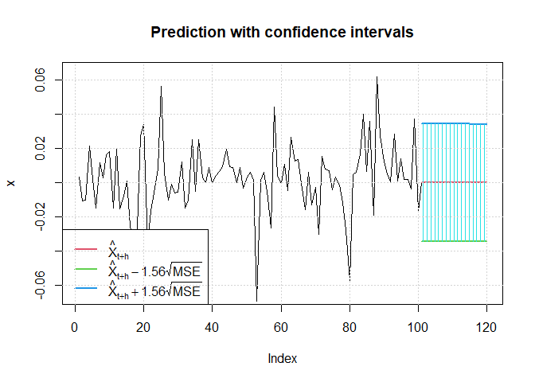

```
##    meanForecast  meanError standardDeviation lowerInterval upperInterval
## 1  1.390915e-05 0.02198594        0.02198594   -0.03427551    0.03430333
## 2  1.390915e-05 0.02198043        0.02198043   -0.03426691    0.03429472
## 3  1.390915e-05 0.02197494        0.02197494   -0.03425834    0.03428616
## 4  1.390915e-05 0.02196947        0.02196947   -0.03424982    0.03427763
## 5  1.390915e-05 0.02196403        0.02196403   -0.03424133    0.03426915
## 6  1.390915e-05 0.02195861        0.02195861   -0.03423288    0.03426070
## 7  1.390915e-05 0.02195321        0.02195321   -0.03422447    0.03425228
## 8  1.390915e-05 0.02194784        0.02194784   -0.03421609    0.03424391
## 9  1.390915e-05 0.02194250        0.02194250   -0.03420775    0.03423557
## 10 1.390915e-05 0.02193718        0.02193718   -0.03419945    0.03422727
## 11 1.390915e-05 0.02193188        0.02193188   -0.03419119    0.03421901
## 12 1.390915e-05 0.02192660        0.02192660   -0.03418296    0.03421078
## 13 1.390915e-05 0.02192135        0.02192135   -0.03417478    0.03420259
## 14 1.390915e-05 0.02191613        0.02191613   -0.03416662    0.03419444
## 15 1.390915e-05 0.02191092        0.02191092   -0.03415851    0.03418632
## 16 1.390915e-05 0.02190574        0.02190574   -0.03415043    0.03417824
## 17 1.390915e-05 0.02190058        0.02190058   -0.03414238    0.03417020
## 18 1.390915e-05 0.02189545        0.02189545   -0.03413437    0.03416219
## 19 1.390915e-05 0.02189034        0.02189034   -0.03412640    0.03415422
## 20 1.390915e-05 0.02188525        0.02188525   -0.03411846    0.03414628
```

```r
predict(m3,n.ahead=20,plot=TRUE,conf=.9,nx=100) # plot con 100 datos y con 90% de nivel de confianza
```

## Modelo VAR BMW-Volkswagen

En este caso se va a trabajar con series mensuales y no diarias, por lo que lo primero que hay que hacer es transformar los datos y seleccionar series mensuales.

```r
## Leer datos
bmw=getSymbols("BMW.DE",env=NULL)
vow=getSymbols("VOW3.DE",env=NULL)
# Generar rentabilidad mensual
rbmw=monthlyReturn(bmw[,6])
rvow=monthlyReturn(vow[,6])
```

```r
#generar un vector
vY=cbind(rbmw,rvow)
colnames(vY)=c("BMW","VOW")
vY=na.omit(vY)
```

```r
#Selección del modelo VAR
VARselect(vY)
```

```
## $selection
## AIC(n)  HQ(n)  SC(n) FPE(n)
##      2      1      1      2
##
## $criteria
##                    1             2             3             4             5
## AIC(n) -9.873837e+00 -9.888421e+00 -9.855114e+00 -9.819385e+00 -9.816003e+00
## HQ(n)  -9.826400e+00 -9.809361e+00 -9.744430e+00 -9.677076e+00 -9.642070e+00
## SC(n)  -9.757037e+00 -9.693756e+00 -9.582583e+00 -9.468987e+00 -9.387739e+00
## FPE(n)  5.150523e-05  5.076121e-05  5.248432e-05  5.440071e-05  5.459637e-05
##                    6             7             8             9            10
## AIC(n) -9.784725e+00 -9.784453e+00 -9.743679e+00 -9.730028e+00 -9.781853e+00
## HQ(n)  -9.579167e+00 -9.547271e+00 -9.474873e+00 -9.429598e+00 -9.449799e+00
## SC(n)  -9.278595e+00 -9.200457e+00 -9.081816e+00 -8.990300e+00 -8.964258e+00
## FPE(n)  5.634796e-05  5.638636e-05  5.876443e-05  5.961259e-05  5.664951e-05
```

**Estimación del Modelo**

```r
#Estimación
model.var=VAR(vY)
summary(model.var)
```

```
##
## VAR Estimation Results:
## =========================
## Endogenous variables: BMW, VOW
## Deterministic variables: const
## Sample size: 166
## Log Likelihood: 344.492
## Roots of the characteristic polynomial:
## 0.1616 0.1616
## Call:
## VAR(y = vY)
##
##
## Estimation results for equation BMW:
## ====================================
## BMW = BMW.l1 + VOW.l1 + const
##
##         Estimate Std. Error t value Pr(>|t|)
## BMW.l1  0.063784   0.102741   0.621    0.536
## VOW.l1 -0.109665   0.075534  -1.452    0.148
## const   0.010420   0.006738   1.547    0.124
##
##
## Residual standard error: 0.08613 on 163 degrees of freedom
## Multiple R-Squared: 0.01368, Adjusted R-squared: 0.001577
## F-statistic:  1.13 on 2 and 163 DF,  p-value: 0.3254
##
##
## Estimation results for equation VOW:
## ====================================
## VOW = BMW.l1 + VOW.l1 + const
##
##        Estimate Std. Error t value Pr(>|t|)
## BMW.l1  0.29944    0.13663   2.192   0.0298 *
## VOW.l1 -0.10529    0.10045  -1.048   0.2961
## const   0.01383    0.00896   1.543   0.1247
## ---
## Signif. codes:  0 '***' 0.001 '**' 0.01 '*' 0.05 '.' 0.1 ' ' 1
##
##
## Residual standard error: 0.1145 on 163 degrees of freedom
## Multiple R-Squared: 0.02978, Adjusted R-squared: 0.01787
## F-statistic: 2.501 on 2 and 163 DF,  p-value: 0.08513
##
##
##
## Covariance matrix of residuals:
##          BMW      VOW
## BMW 0.007418 0.006425
## VOW 0.006425 0.013118
##
## Correlation matrix of residuals:
##        BMW    VOW
## BMW 1.0000 0.6514
## VOW 0.6514 1.0000
```

```r
model.var1=VAR(vY,type="none")
summary(model.var1)
```

```
##
## VAR Estimation Results:
## =========================
## Endogenous variables: BMW, VOW
## Deterministic variables: none
## Sample size: 166
## Log Likelihood: 343.033
## Roots of the characteristic polynomial:
## 0.1564 0.1564
## Call:
## VAR(y = vY, type = "none")
##
##
## Estimation results for equation BMW:
## ====================================
## BMW = BMW.l1 + VOW.l1
##
##        Estimate Std. Error t value Pr(>|t|)
## BMW.l1  0.06870    0.10313   0.666    0.506
## VOW.l1 -0.10102    0.07565  -1.335    0.184
##
##
## Residual standard error: 0.08649 on 164 degrees of freedom
## Multiple R-Squared: 0.01112, Adjusted R-squared: -0.0009436
## F-statistic: 0.9218 on 2 and 164 DF,  p-value: 0.3999
##
##
## Estimation results for equation VOW:
## ====================================
## VOW = BMW.l1 + VOW.l1
##
##        Estimate Std. Error t value Pr(>|t|)
## BMW.l1  0.30596    0.13714   2.231    0.027 *
## VOW.l1 -0.09382    0.10059  -0.933    0.352
## ---
## Signif. codes:  0 '***' 0.001 '**' 0.01 '*' 0.05 '.' 0.1 ' ' 1
##
##
## Residual standard error: 0.115 on 164 degrees of freedom
## Multiple R-Squared: 0.03183, Adjusted R-squared: 0.02002
## F-statistic: 2.696 on 2 and 164 DF,  p-value: 0.07047
##
##
##
## Covariance matrix of residuals:
##          BMW      VOW
## BMW 0.007374 0.006388
## VOW 0.006388 0.013041
##
## Correlation matrix of residuals:
##        BMW    VOW
## BMW 1.0000 0.6514
## VOW 0.6514 1.0000
```

**Causalidad de Granger**

Modelo de Causalidad de Granger, donde se prueba si la variable es útil para seleccionar variables.

```r
causality(model.var1)
```

```
## $Granger
##
##  Granger causality H0: BMW do not Granger-cause VOW
##
## data:  VAR object model.var1
## F-Test = 4.9775, df1 = 1, df2 = 328, p-value = 0.02636
##
##
## $Instant
##
##  H0: No instantaneous causality between: BMW and VOW
##
## data:  VAR object model.var1
## Chi-squared = 49.984, df = 1, p-value = 1.55e-12
```

p-value es menor que 0.05, por lo que se rechazaria la hipótesis nula de no causalidad entre BMW y Voklwagen.

**Respuesta al impulso**

El análisis de respuesta de impulso, mide la respuesta de una variable ante un cambio.

```r
#respuesta al impulso
model.ri=irf(model.var1)
model.ri
```

```
##
## Impulse response coefficients
## $BMW
##                 BMW           VOW
##  [1,]  8.649037e-02  7.549359e-02
##  [2,] -1.685085e-03  1.937922e-02
##  [3,] -2.073499e-03 -2.333775e-03
##  [4,]  9.332459e-05 -4.154380e-04
##  [5,]  4.837964e-05  6.753077e-05
##  [6,] -3.498688e-06  8.466109e-06
##  [7,] -1.095613e-06 -1.864759e-06
##  [8,]  1.131195e-07 -1.602524e-07
##  [9,]  2.395991e-08  4.964491e-08
## [10,] -3.369331e-09  2.672851e-09
## [11,] -5.014760e-10 -1.281641e-09
```

[output cut: 74 more lines]

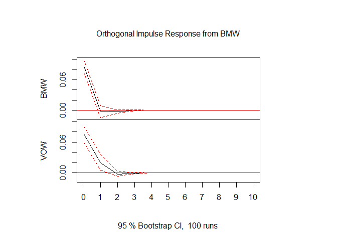

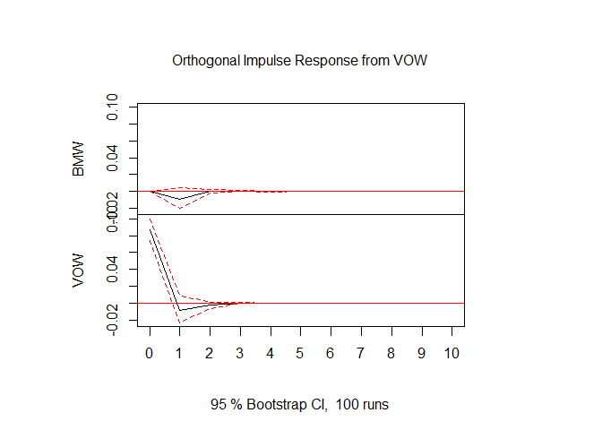

```r
plot(model.ri)
```

**Predicción del modelo**

Las predicciones del modelo, para BMW y para Voklswagen, por tanto serían las siguientes:

```
## $BMW
##               fcst      lower     upper        CI
## [1,]  5.655493e-05 -0.1694615 0.1695746 0.1695180
## [2,] -6.008855e-03 -0.1764273 0.1644095 0.1704184
## [3,]  1.496040e-04 -0.1703178 0.1706170 0.1704674
## [4,]  1.432373e-04 -0.1703248 0.1706112 0.1704680
## [5,] -7.259004e-06 -0.1704753 0.1704608 0.1704680
## [6,] -3.321659e-06 -0.1704713 0.1704647 0.1704680
## [7,]  2.610443e-07 -0.1704678 0.1704683 0.1704680
## [8,]  7.469939e-08 -0.1704679 0.1704681 0.1704680
##
## $VOW
##               fcst      lower     upper        CI
## [1,]  5.951869e-02 -0.1659047 0.2849421 0.2254234
## [2,] -5.566908e-03 -0.2347240 0.2235902 0.2291571
## [3,] -1.316142e-03 -0.2305497 0.2279175 0.2292336
## [4,]  1.692564e-04 -0.2290663 0.2294048 0.2292356
## [5,]  2.794420e-05 -0.2292077 0.2292636 0.2292356
## [6,] -4.842739e-06 -0.2292405 0.2292308 0.2292356
## [7,] -5.619218e-07 -0.2292362 0.2292350 0.2292356
## [8,]  1.325891e-07 -0.2292355 0.2292357 0.2292356
```